# Homework1

BenLarson

January 23, 2016

# 1. Problem 1

+1a $E[E[X|Y]] = E[X]$ https://en.wikipedia.org/wiki/Law_of_total_expectation $E[E[X|Y]] = E_y[\sum_x xP(X=x|Y=y)]$ $=\sum_y [\sum_x xP(X=x|Y=y)] P(Y=y)$ $=\sum_y \sum_x xP(X=x|Y=y) P(Y=y)$ $=\sum_x x \sum_y P(X=x|Y=y) P(Y=y)$ $=\sum_x x P(X=x|Y=y)$ $=\sum_x xP(X=x) = E[X]$

+1b $Var(X) = E[Var(X|Y)] + Var(E[X|Y])$ https://en.wikipedia.org/wiki/Law_of_total_variance  
Writing this out in 2 steps makes the math easier to see.  
Step 1:  
$E[Var[X|Y] = E[E[X|Y]^2 + [E[X|Y]]^2] = E[E[X^2|Y]] = E[X^2]$ Step 2: $Var[E[X|Y]] = E[[E[X|Y]]^2]-[E[E[X|Y]]]^2 = [E[E[X|Y]]]^2 = [E[X]]^2$ combining we get:  
$Var(X) = E[X^2] - E[X]^2$  
————————————————————————————  
+ 2a $g(x)=\int{f(x,y)}dy=\int_{-1}^1{(x+y)dy}=xy+\frac{y^2}{2}=x+\frac{1}{2}$ ————————————————————————————  
+ 2b $w(y|x)=\frac{f(x,y)}{g(x)}=\frac{x+y}{x+\frac{1}{2}} \quad 0\le x\le 1 \\$ ————————————————————————————  
+ 2c Conditional expectation  
$E[Y|X]=\int_0^1{y p(y|x)dy}$ using: p(y|x) = $\frac{x+y}{x+1}$  
$=\int_0^1 y*\frac{x+y}{x+1\2}dy$  
$=\int_0^1{\frac{xy}{x+1/2}}dy+\int_0^1{\frac{y^2}{x+1/2}dy}$ $\frac{y^2x}{2(x+1/2)}+\frac{y^3}{3(x+1/2)}\big|_0^1= \frac{x}{2x+1}+\frac{1}{3x+3/2}$ + 2d  
$\sigma_{X|Y} = E[X|Y] - E[X]E[Y]$ $E[X]= \int_0^1\int_0^1 x(x+y)dydx = \int_0^1\int_0^1 x^2+xy dydx= \int_0^1 x^2+\frac{x}{2}dx = \frac{x^3}{3}+\frac{x^2}{2*2}\big|_0^1=\frac{7}{12}$ $E[Y] = \int_0^1\int_0^1y(x+y)dydx = \int_0^1\int_0^1y^2+xy dydx=\int_0^1\frac{1}{3}+\frac{x}{2}dx =\frac{x}{3}+\frac{x^2}{2*2}\big|_0^1 = \frac{7}{12}$ $E[Y|X] = \int_0^1\int_0^1 xy(x+y)dydx=\int_0^1\int_0^1 x^2y+y^2xdydx = \int_0^1\frac{x^2y^2}{2}+\frac{y^3x}{3}dx = \frac{x^3}{6}+\frac{x^2}{6}\big|_0^1 = \frac{1}{3}$ $\sigma_{X|Y} = E[X|Y] - E[X]E[Y]=\frac{1}{3} - \frac{7}{12}\frac{7}{12}=\frac{-1}{144}=-0.0069$ ——————————————————————————————————————————  
# 3. Problem 3  
+ 3a We find the density function using the equation: $f(w(y))*|w'(y)|$  
$Y=\sqrt{X}$ $X = Y^2$ $w'(y) = \frac{dx}{dy} = 2y$ We get the density function by: $p(y) = \lambda e^{-\lambda y^2}|2y| = 2y\lambda e^{-\lambda y^2}$ ——————————————————————————————————————————  
+ 3b Cumulative Distribution function: $F(y) = P(Y\le y)$ $F(y) = \int_0^y \lambda 2ye^{-\lambda y^2}dy$ $F(y) = 2\lambda \int_0^y ye^{-\lambda y^2}dy$ $= -e^{-\lambda y^2}\big|_0^y$ $= -e^{-\lambda y^2}+1$ Verify F(0) = 0 and $F(\inf)=1$  
https://en.wikipedia.org/wiki/Quantile_function  
$F(0)=-e^{0}+1 = 0$ and $F(\inf) = e^{-\inf}+1 = 0-1 = 1$ ——————————————————————————————————————————  
+ 3c Quantile Function $F^{-1}$  
$1-e^{-\lambda q^2} = y$ $e^{-\lambda q^2} = 1-y$ $-\lambda q^2 = ln(1-y)$ $q=\sqrt{ \frac{ln(1-y)}{-\lambda}}$ ——————————————————————————————————————————  
+ 3d find E[Y], Var(Y) $E[Y] = \int y *f(y) dy = \int 2y^2 \lambda e^{-\lambda*y^2}dy$ $u = y$ $dv = 2\lambda y e^{-\lambda y^2}dy$ $du = dy$ $v = -e^{-\lambda y^2}$ To intgrate $e^{-x^2}$ used the solution from: http://math.stackexchange.com/questions/154968/is-there-really-no-way-to-integrate-e-x2 $\int e^{-x^2} = \sqrt{\pi}$ or with a constant we can say: $\int e^{-\lambda x^2} = \sqrt{\frac{\pi}{\lambda}}$ https://en.wikipedia.org/wiki/Gaussian_integral $uv - \int vdu = ye^{-\lambda y^2} - \int -e^{-\lambda y^2}dy$ $E[Y] = ye^{-\lambda y^2} + \sqrt{\frac{\pi}{\lambda}}$ ———————————————————————————————– $E[Y^2] = \int y^2 *f(x)dx = \int 2y^3\lambda e^{-\lambda*y^2}dy$ $u = y^2$ $dv = 2\lambda y e^{-\lambda y^2}dy$ $du = 2ydy$ $v = -e^{-\lambda y^2}$ $uv - \int vdu = -y^2e^{-\lambda y^2} - \int -2ye^{-\lambda y^2}dy$ $\int 2ye^{-\lambda y^2}dy = \frac{-1}{\lambda} e^{-\lambda y^2}$ $E[Y^2] = -y^2e^{-\lambda y^2}+ \frac{-1}{\lambda} e^{-\lambda y^2}$ Variance can now be solved for: $var(Y) = E[Y^2]-E[Y]^2$ $= -y^2e^{-\lambda y^2}+ \frac{-1}{\lambda} e^{-\lambda y^2} - (ye^{-\lambda y^2} + \sqrt{\frac{\pi}{\lambda}})^2$ ———————————————————————————————————————————–  
# 4. Problem 4 Find the MLE for Y from the pdf above $p(y)=\lambda 2ye^{-\lambda y^2}$ $L(\lambda)=\prod_1^n{\lambda 2y_ie^{-\lambda y_i^2}}$ We take the log of both sides then differentiate to find the MLE for $\lambda$. $\frac{d(ln(L(X)))}{d\lambda}= \frac{d(n ln(2\lambda))}{d\lambda}+\frac{d(ln\prod(y_ie^{-y_i^2\lambda})}{d\lambda} = 0$ Split the terms and differentiate to make the math easier. $\frac{d(n ln(2\lambda))}{d\lambda}= \frac{n}{\lambda}$ $\frac{d(ln \prod{y_i e^{-y_i^2\lambda}})}{d\lambda} = \frac{d(ln(\prod{y_i}) + ln(\prod{e^{-\lambda y_i^2}})))}{d\lambda} = \frac{d(\sum{ln(y_i)} + \sum{ln e^{-\lambda y_i^2}})}{d\lambda} = 0 - \sum{y_i^2}$ combine our results to get: $0 = \frac{n}{\lambda} - \sum y_i^2$ solve for lambda: $\frac{n}{\lambda} -\sum{y_i^2} = 0$ $\lambda = \frac{n}{\sum{y_i^2}}$

# Coding Section

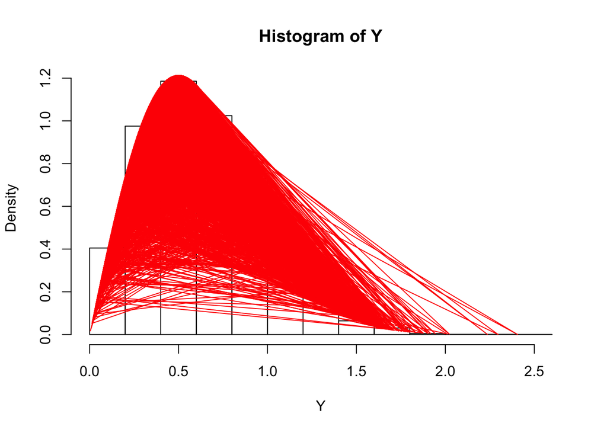

```r
# This function takes a number a lambda value for the Y = sqrt(X) exponential distribution
exp_function <- function(n,lam)
{
  x <- c(runif(n))
  Y <-sqrt(log(1-x)/-lam)
  return (Y)
}
Y = exp_function(10000,2)
hist(Y, freq=FALSE)
lines(Y,2*2*Y*exp(-2*Y^2), col="red")
```

$E[Y] = ye^{-\lambda y^2} + \sqrt{\frac{\pi}{\lambda}}$ $Var(Y) = -y^2e^{-\lambda y^2}+ \frac{-1}{\lambda} e^{-\lambda y^2} - (ye^{-\lambda y^2} + \sqrt{\frac{\pi}{\lambda}})^2$

```r
#Calculate the Mean and Variance for the Y distribution
mean(Y)
```

```
## [1] 0.6272519
```

```r
#my E[Y]
Ey = 1*exp(-2*1) + sqrt(pi/2)
print (Ey)
```

```
## [1] 1.388649
```

```r
var(Y)
```

```
## [1] 0.1090054
```

```r
#my var(Y)
Vy = exp(-2)-1/2*exp(-2) - (exp(-2)+sqrt(pi/2))^2 - 1/2
print (Vy)
```

```
## [1] -2.36068
```

My expected value and variance did not work out correctly. I’m not sure if I’m plugging the values [0,1] correctly or if my math is wrong above.

```r
#Log Likelihood
n = 20
rlz <- exp_function(n,2)
MLE_Estimate = n/sum(rlz^2)
l <-c(1:20)/5
place = array(data = 1, dim = 20)
# lglik = n*log(2*l) + sum(log(rlz))+sum(log(exp(-l*rlz^2)))
lglik <- 0
for(i in 1:20)
{
  lglik[i] <- prod(l[i]*2*rlz*exp(-l[i]*rlz^2))
}
MLE_Estimate
```

```
## [1] 2.055303
```

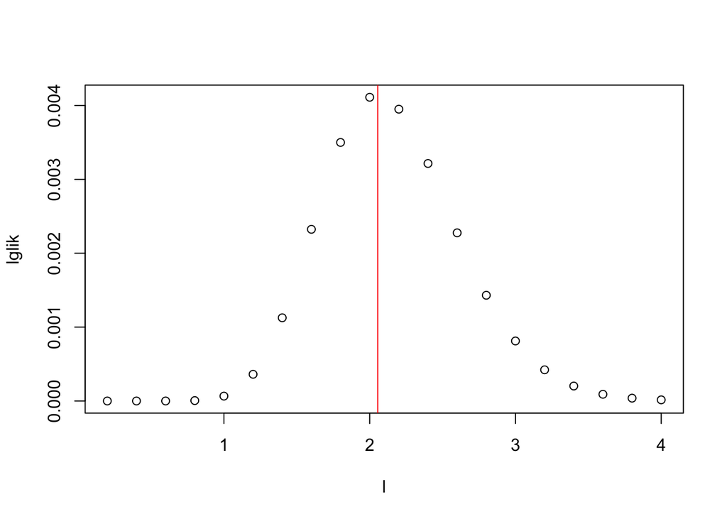

```r
plot(l,lglik)
abline(v=MLE_Estimate, col="red")
```